# Maven Analytics - Remote Working Survey Challenge

## About the dataset

This dataset contains the results of two surveys of 1,500 remote workers commissioned by the state of New South Wales (NSW). The first took place in August and September 2020, and aimed to capture the remote work experiences and attitudes at the height of the COVID lockdown. Once health restrictions were reduced and a return to lockdown seemed unlikely, a similar survey was conducted between March and April 2021.

To be eligible, survey respondents had to be employed NSW residents with remote working experience in their current job. This means that both unemployed people and those whose job cannot be done remotely were not taken into account. The resulting sample represents roughly 59% of the NSW workforce.

The responses are stored in 2 csv tables, one for each survey.

Each record represents a single respondent, and contains answers to questions on:

- Their employers’ policies, practices, and attitudes for remote work
- Their own attitude towards working remotely
- The amount of time they spent working remotely, and how they spent it
- The barriers they faced when working remotely, and how they have changed
- The best and worst aspects of working remotely
- Their expectations for working remotely in the future

The dataset can be downloaded here: https://maven-datasets.s3.amazonaws.com/Remote+Working+Survey/NSW+Remote+Working+Survey.zip

## How to play the Maven Remote Work Challenge

For this challenge, your task is to **assess the productivity and morale implications of working remotely and outline an ideal policy for the post-pandemic future**, presented in the form of a single-page report or dashboard.

## This notebook

The purpose of this notebook is to prepare the survey data for a variety of analyses.

Cleaning data in this way is an iterative process but using a notebook like this helps immensely in getting immediate feedback on the transformations which are being applied to the data.

### Imports and setup

First we'll import any libraries, download and extract the raw data

```python
import pandas as pd # for general data management
from fuzzywuzzy import fuzz # we'll use this for fuzzy matching of column names between files
from fuzzywuzzy import process # this lets us use fuzzy matching in a lambda function
import requests
import os
from io import BytesIO
from urllib.request import urlopen
from zipfile import ZipFile

# an environment variable containing a root folder path on my computer
blog_folder_path = os.environ['BLOG_FOLDER_PATH']

# the raw data for the challenge
url = "https://maven-datasets.s3.amazonaws.com/Remote+Working+Survey/NSW+Remote+Working+Survey.zip"

# read the zip file
zip_file = requests.get(url)
zip_content = ZipFile(BytesIO(zip_file.content))

# check the names of the files in the zip
print('The downloaded zip files contains these files:')
print(zip_content.namelist())

# extract the files to the current working directory (same as ipynb unless set otherwise)
zip_content.extractall()

# create a directory string to use throughout this notebook
s = blog_folder_path + r'\Maven Challenges\Remote Working Survey' + '\\'
```

```
The downloaded zip files contains these files:
['2020_rws.csv', '2021_rws.csv']
```

First, let's grab both csv files as separate dataframes so their structure can be compared.

Note: I found that attempting to use read_csv without specifying the encoding resulted in error "'utf-8' codec can't decode byte 0x92". This page suggested Windows Codepage 1252, indicating that the problem is like with an apostrophe character being used in the raw data.

https://stackoverflow.com/questions/46000191/utf-8-codec-cant-decode-byte-0x92-in-position-18-invalid-start-byte

Attempting to decode with latin1 confirms this as the apostrophe in the word "employer's" is not displayed correctly.

```python
df_2020_rws = pd.read_csv(s + '2020_rws.csv', encoding = 'cp1252')
df_2021_rws = pd.read_csv(s + '2021_rws.csv', encoding = 'cp1252')
```

To make analysis easier, one goal will be to append both datasets together. This is not necessarily a trivial task since:

- The surveys in each year may have asked different questions (question is in one year and not the other)
- Questions which are asking the same thing may be asked in a different way, or rather, the column header is different for the same question
- Questions asked in both years may present different but equivalent options (e.g. "Somewhat likely" vs. "Somewhat agree")

## Matching columns between years

First, we'll use fuzzy matching and a little manual work in Excel to match the variables from one year with the next and give the variables shorter names.

Just to check it's actually worth doing this, let's see if there are differences in the column headers:

```python
coldiff = pd.Series(df_2020_rws.columns.difference(df_2021_rws.columns))

print('There are {} column header differences between the two files'.format(coldiff.count()))
```

[output not shown]

So, we need to first create a mapping between the column headers of each file. We'll do this by taking the column headings and fuzzy matching against the headings from the other file. The match score will serve as a useful guide to whether two headings represent the same question or not. It won't be perfect, but it will be a good start.

We can then output the comparison to Excel for some manual work and assigning variable groups to the questions.

```python
# first, convert the columns (which are Index objects) into dataframes
cols20 = pd.DataFrame(df_2020_rws.columns)
cols20.columns = ['col2020']
cols21 = pd.DataFrame(df_2021_rws.columns)
cols21.columns = ['col2021']

# then cross-join the two lists, so each row in the result has a combination of one column from 2020 and one column from 2021
cols20['one'] = 1
cols21['one'] = 1
df_cols_crossjoin = pd.merge(cols20,cols21,on = 'one').drop('one',axis=1)
df_cols_crossjoin.head()
```

|  | col2020 | col2021 |
| --- | --- | --- |
| 0 | Response ID | Response ID |
| 1 | Response ID | What year were you born? |
| 2 | Response ID | What is your gender? |
| 3 | Response ID | How long have you been in your current job? I... |
| 4 | Response ID | Which of the following best describes your ind... |

Here we use fuzzywuzzy's fuzz.ratio function to get the best match for each question. Using a lambda function with apply like this is not particularly quick.

```python
# apply the fuzzy matching and add a column returning the score
df_cols_crossjoin['fuzz_ratio'] = df_cols_crossjoin.apply(lambda x: fuzz.ratio(x.col2020,
                                                                               x.col2021),
                                                          axis=1)
df_cols_crossjoin.head()
```

|  | col2020 | col2021 | fuzz_ratio |
| --- | --- | --- | --- |
| 0 | Response ID | Response ID | 100 |
| 1 | Response ID | What year were you born? | 22 |
| 2 | Response ID | What is your gender? | 30 |
| 3 | Response ID | How long have you been in your current job? I... | 9 |
| 4 | Response ID | Which of the following best describes your ind... | 18 |

We can write the crossjoin of column matches to a csv file and inspect it with Excel.

```python
df_cols_crossjoin.to_csv(s + 'cols_comparison.csv', encoding = 'cp1252', index = False)
```

The method above is comprehensive in that it compares each header from one file with each header from another.

However, since we're only interested in the top scoring match per field, we can create a shorter file by just extracting the best match.

First, we will need to work with the columns of each file as lists:

```python
col20 = df_2020_rws.columns.tolist()
col21 = df_2021_rws.columns.tolist()
```

We create a dataframe using the col20 list of columns and append to it a dataframe created from the col21 list of columns.

Note that this can be done with a single line, but to maintain readability and attempt to keep under 80 characters per line (per PEP-8), we should split the work onto several lines.

```python
# create dataframes of the columns from each year
df20 = pd.DataFrame({'col_name' : col20, 'year' : 2020})
df21 = pd.DataFrame({'col_name' : col21, 'year' : 2021})

# append the dataframes together
df_colmatch = pd.concat([df20, df21]).reset_index().drop('index', axis=1)

print(df_colmatch.groupby('year')['col_name'].count())

df_colmatch.head()
```

```
year
2020     73
2021    109
Name: col_name, dtype: int64
```

|  | col_name | year |
| --- | --- | --- |
| 0 | Response ID | 2020 |
| 1 | What year were you born? | 2020 |
| 2 | What is your gender? | 2020 |
| 3 | Which of the following best describes your ind... | 2020 |
| 4 | Which of the following best describes your ind... | 2020 |

In order to use fuzzy matching more quickly than the lambda method above, we can use process.extract from fuzzywuzzy.

This method takes an item, then compares it to every item in a list.

So, in this example, we'll take each column header from one year and compare it with all the column headers from the other year.

To do this, we need the column headers as lists.

We can then put both lists in a list - a list of lists - then apply the same matching process in both directions (just in case).

```python
# create a list of the two lists
cols = [col20,col21]

# then, for each of those lists
for ls in cols:

    # we want to match items in 2020 with the list for 2021
    # and match items in 2021 with the list for 2020
    if cols.index(ls) == 0:
        matches = cols[1]
    else:
        matches = cols[0]

    # for each item in the current list
    for i in ls:

        # where the col_name column is the current item and the year is the current year
        # cols.index(ls) = 0 for 2020, 1 for 2021
        mask = (df_colmatch.col_name == i) & (df_colmatch.year == 2020 + cols.index(ls))

        # get these columns from the result produced by process.extract
        flds = ['best_match','fuzz_ratio']

        # extract the best match (limit=1) at the 0th index
        # (in order to get the values rather than a list of values)
        df_colmatch.loc[mask,flds] = process.extract(i,
                                                     matches,
                                                     limit = 1,
                                                     scorer = fuzz.ratio)[0]

# the output is one row per question, with the best match of that question with the list of
# questions from the other year
df_colmatch
```

|  | col_name | year | best_match | fuzz_ratio |
| --- | --- | --- | --- | --- |
| 0 | Response ID | 2020 | Response ID | 100.0 |
| 1 | What year were you born? | 2020 | What year were you born? | 100.0 |
| 2 | What is your gender? | 2020 | What is your gender? | 100.0 |
| 3 | Which of the following best describes your ind... | 2020 | Which of the following best describes your ind... | 100.0 |
| 4 | Which of the following best describes your ind... | 2020 | Which of the following best describes your ind... | 90.0 |
| ... | ... | ... | ... | ... |
| 177 | How strongly do you agree or disagree with the... | 2021 | Thinking about remote working last year, how s... | 71.0 |
| 178 | How strongly do you agree or disagree with the... | 2021 | Thinking about remote working last year, how s... | 65.0 |
| 179 | How strongly do you agree or disagree with the... | 2021 | Thinking about remote working last year, how s... | 71.0 |
| 180 | This question is about your productivity. Prod... | 2021 | This question is about your productivity. Prod... | 100.0 |
| 181 | Now think about the productivity of the employ... | 2021 | Thinking about remote working in the last 3 mo... | 54.0 |

182 rows × 4 columns

We've created a dataframe containing one row per column from each file. Each row has the best match from the other file listed in a separate column, as well as the match score.

This will be far from perfect, but it will serve as a decent guide when trying to standardize the column names.

Now we write the the matches to a csv so we can edit manually in Excel.

```python
df_colmatch.to_csv(s + 'df_colmatch.csv', encoding = 'cp1252', index = False)
```

At this point, it was useful to load the file into Excel, format as a Table, add some columns to categorize the data, then save as xlsx.

## After matching columns between years

To make the creation of various data tables easier, we'll stack the data. As far as storage or long-term data architecture is concerned, this is definitely an anti-pattern, but it's usable as an interim measure while we get organized.

In many of the original columns, there are missing values. This can be problematic later and we definitely want to distinguish between values that were missing in the raw data and values that may have become missing due to some processing error. So, first we fill the NA cells in each of the raw dataframes with a default value. Here, a missing value can either mean 'No answer' (i.e. the respondent was asked, but did not respond), or it can mean 'Not applicable', which is usually when the survey routing has bypassed a question because of a response given to an earlier question. For example, if a respondent is not a manager, they don't need to answer questions about managing remote teams.

```python
# add a year column to each source file's dataframe
df_2020_rws['year'] = 2020
df_2021_rws['year'] = 2021

# provide a default value to cells with no value
df_2020_rws.fillna('No answer / not applicable',inplace=True)
df_2021_rws.fillna('No answer / not applicable',inplace=True)

# "melt" (AKA unpivot) each dataframe, keeping the year and response ID on each row
df_melt20 = pd.melt(df_2020_rws, id_vars = ['year','Response ID'])
df_melt21 = pd.melt(df_2021_rws, id_vars = ['year','Response ID'])

# append the dataframes together
df_melt = pd.concat([df_melt20, df_melt21]).reset_index().drop('index', axis=1)

# take a look at the result
df_melt
```

|  | year | Response ID | variable | value |
| --- | --- | --- | --- | --- |
| 0 | 2020 | 1 | What year were you born? | 1972 |
| 1 | 2020 | 2 | What year were you born? | 1972 |
| 2 | 2020 | 3 | What year were you born? | 1982 |
| 3 | 2020 | 4 | What year were you born? | 1987 |
| 4 | 2020 | 5 | What year were you born? | 1991 |
| ... | ... | ... | ... | ... |
| 271795 | 2021 | 1508 | Now think about the productivity of the employ... | I’m 30% more productive when working remotely |
| 271796 | 2021 | 1509 | Now think about the productivity of the employ... | My productivity is about same when I work remo... |
| 271797 | 2021 | 1510 | Now think about the productivity of the employ... | No answer / not applicable |
| 271798 | 2021 | 1511 | Now think about the productivity of the employ... | My productivity is about same when I work remo... |
| 271799 | 2021 | 1512 | Now think about the productivity of the employ... | No answer / not applicable |

271800 rows × 4 columns

You can see above that we have one row for each response to every question in both years. Those variable names are very long.

When we create a single file containing both years, we'll want names which are a bit more easy to work with.

So, we'll grab the standardized column names and variable groups from the Excel file we created earlier.

```python
df_colmatch_std = pd.read_excel(s + 'df_colmatch.xlsx', usecols = 'A:B,G:H')
df_colmatch_std
```

|  | col_name | year | var_name_edit | var_group_1 |
| --- | --- | --- | --- | --- |
| 0 | Response ID | 2020 | resp_id | Demographics |
| 1 | What year were you born? | 2020 | year_born | Demographics |
| 2 | What is your gender? | 2020 | gender | Demographics |
| 3 | Which of the following best describes your ind... | 2020 | industry | Demographics |
| 4 | Which of the following best describes your ind... | 2020 | industry_detail | Demographics |
| ... | ... | ... | ... | ... |
| 177 | How strongly do you agree or disagree with the... | 2021 | manage_remote_feel_well_prepared | Managing people remotely |
| 178 | How strongly do you agree or disagree with the... | 2021 | manage_remote_focus_results | Managing people remotely |
| 179 | How strongly do you agree or disagree with the... | 2021 | manage_remote_easy_contact_team | Managing people remotely |
| 180 | This question is about your productivity. Prod... | 2021 | remote_productivity_per_hour | Remote productivity |
| 181 | Now think about the productivity of the employ... | 2021 | remote_productivity_per_hour_team | Remote productivity |

182 rows × 4 columns

In case it's useful later, we can save these standardized column matchings to a new csv (which is independent of the Excel file they originate from)

```python
df_colmatch_std.to_csv(s + 'df_colmatch_std.csv', encoding = 'cp1252', index = False)
```

There are some variables where question answers between years are inconsistently formatted. We might be able to reduce some of the inconsistency by applying some simple text cleanup.

We'll merge the standardized variable names with the melted dataset created above.

Then apply some simple transformations to clean up some of the inconsistencies

```python
# merge the melted dataset with the standardized column names
df_melt2 = pd.merge(df_melt,
                   df_colmatch_std,
                   left_on = ['variable','year'],
                   right_on = ['col_name','year'],
                   how = 'inner').copy()

# .astype(str) is necessary here otherwise numeric values are returned as NaN after .str
df_melt2['value'] = df_melt2['value'].astype(str)

# trim leading and trailing whitespace
df_melt2['value'] = df_melt2['value'].str.strip()

# remove double-spacing inside the string
df_melt2['value'] = df_melt2['value'].replace('  ',' ')

# replace an inconsistency in the gender variable
df_melt2['value'] = df_melt2['value'].replace('Rather not say',
                                              'I would rather not say')

# one year said "or worse", one year said "or less"
df_melt2['value'] = df_melt2['value'].replace('I’m 50% less productive when working remotely (or worse)',
                                              'I’m 50% less productive when working remotely (or less)')
```

Some questions have numeric answers, so we don't want that generic text for no answer in there

```python
flds = ['remote_pay_cut_max']
mask = (df_melt2.var_name_edit.isin(flds) \
        | df_melt2.var_name_edit.str.startswith('onsite_time_spent')) \
        & (df_melt2.value == 'No answer / not applicable')

print(df_melt2.loc[mask].var_name_edit.unique())

df_melt2.loc[mask,'value'] = 0
```

```
['onsite_time_spent_prep' 'onsite_time_spent_working'
 'onsite_time_spent_caring' 'onsite_time_spent_personal'
 'onsite_time_spent_sleep' 'remote_pay_cut_max']
```

The "industry" question asks people what industry they work in. In 2020, many of the responses had a suffix " Services", where the equivalent industry in 2021 did not have that suffix.

```python
mask = (df_melt2.var_name_edit == 'industry')
grps = ['value','year']

chk = df_melt2.loc[mask].groupby(grps)['Response ID'].count()

print(chk)
```

```
value                                            year
Accommodation and Food                           2021     27
Accommodation and Food Services                  2020     32
Administrative and Support                       2021     70
Administrative and Support Services              2020     76
Agriculture, Forestry and Fishing                2020      9
                                                 2021     14
Arts and Recreation                              2021     35
Arts and Recreation Services                     2020     38
Construction                                     2020     56
                                                 2021     71
Education and Training                           2020    144
                                                 2021    150
Electricity, Gas, Water and Waste                2021     28
Electricity, Gas, Water and Waste Services       2020     29
Financial and Insurance                          2021    204
Financial and Insurance Services                 2020    173
Health Care and Social Assistance                2020    103
                                                 2021    116
Information Media and Telecommunications         2020    114
                                                 2021    149
Manufacturing                                    2020     82
                                                 2021     67
Mining                                           2020      8
                                                 2021     15
Other Services                                   2020     90
                                                 2021    132
Professional, Scientific and Technical           2021    163
Professional, Scientific and Technical Services  2020    259
Public Administration and Safety                 2020     81
                                                 2021     66
Rental, Hiring and Real Estate                   2021     22
Rental, Hiring and Real Estate Services          2020     25
Retail Trade                                     2020     87
                                                 2021     86
Transport, Postal and Warehousing                2020     57
                                                 2021     47
Wholesale Trade                                  2020     44
                                                 2021     50
Name: Response ID, dtype: int64
```

We can strip that suffix from both industry and industry detail (the latter is only in 2020 anyway)

```python
# create a series of True/False to search for rows to update
mask = (df_melt2['value'].str.endswith(' Services')) \
        & (df_melt2['var_name_edit'].isin(['industry',
                                          'industry_detail']))

# update the rows by removing the text from the end of the string
df_melt2.loc[mask, 'value'] = df_melt2.loc[mask].value.str[:-len(' Services')]
```

A similar problem exists in the occupation questions, where one year has a suffix " workers" and the other year doesn't

```python
# now do the same for the word 'workers' in occupation variables
mask = (df_melt2['value'].str.lower().str.endswith(' workers')) \
        & (df_melt2['var_name_edit'].isin(['occupation',
                                          'occupation_detail']))

# update the rows by removing the text from the end of the string
df_melt2.loc[mask, 'value'] = df_melt2.loc[mask].value.str[:-len(' Workers')]
```

There is an inconsistency in the org_size question, where one year uses "I am the only employee" and the other uses "I am a sole trader/owner-operator"

```python
mask = (df_melt2['value'] == 'I am the only employee') \
        & (df_melt2['var_name_edit'] == 'org_size')

# update the rows by removing the text from the end of the string
df_melt2.loc[mask, 'value'] = 'I am a sole trader/owner-operator'
```

The surveys included questions about how an employer might react to COVID-19 being cured or eradicated.

Unfortunately the value labels are not consistent between the two years.

We can see that in 2020, the labels use the words "agree" and "disagree" and in 2021 they use the words "likely" and "unlikely".

```python
mask = df_melt2.variable.str.contains('likely', case = False)
df_melt2[mask].groupby(['var_name_edit', 'year', 'value'])['Response ID'].count()
```

```
var_name_edit                    year  value
covid_remote_employer_changes    2020  Neither agree nor disagree    358
                                       Somewhat agree                540
                                       Somewhat disagree             175
                                       Strongly agree                331
                                       Strongly disagree             103
                                 2021  Neither unlikely or likely    424
                                       Somewhat likely               479
                                       Somewhat unlikely             183
                                       Very likely                   250
                                       Very unlikely                 176
covid_remote_employer_encourage  2020  Neither agree nor disagree    328
                                       Somewhat agree                506
                                       Somewhat disagree             237
                                       Strongly agree                302
                                       Strongly disagree             134
                                 2021  Neither unlikely or likely    410
                                       Somewhat likely               370
                                       Somewhat unlikely             280
                                       Very likely                   239
                                       Very unlikely                 213
covid_remote_more_choice         2020  Neither agree nor disagree    312
                                       Somewhat agree                547
                                       Somewhat disagree             165
                                       Strongly agree                367
                                       Strongly disagree             116
                                 2021  Neither unlikely or likely    384
                                       Somewhat likely               455
                                       Somewhat unlikely             222
                                       Very likely                   254
                                       Very unlikely                 197
Name: Response ID, dtype: int64
```

So, we can change the 2020 labels to match those used in 2021

```python
# create a list of the questions we want to work on
varlist = ['covid_remote_more_choice',
           'covid_remote_employer_encourage',
           'covid_remote_employer_changes']

# create a dictionary mapping the unwanted value to the replacement value
mapdict = {'Neither agree nor disagree' : 'Neither unlikely or likely',
           'Somewhat agree' : 'Somewhat likely',
           'Somewhat disagree' : 'Somewhat unlikely',
           'Strongly agree' : 'Very likely',
           'Strongly disagree' : 'Very unlikely'}

# create a filter criteria
mask = df_melt2.var_name_edit.isin(varlist) & df_melt2.value.isin(mapdict)

# update the value with the corresponding value found for that key in the dictionary
df_melt2.loc[mask,'value'] = df_melt2.loc[mask,'value'].map(mapdict)

# and check the results
mask = df_melt2.var_name_edit.isin(varlist)
flds = ['var_name_edit','year','value']
df_melt2[mask].groupby(flds)['Response ID'].count()
```

```
var_name_edit                    year  value
covid_remote_employer_changes    2020  Neither unlikely or likely    358
                                       Somewhat likely               540
                                       Somewhat unlikely             175
                                       Very likely                   331
                                       Very unlikely                 103
                                 2021  Neither unlikely or likely    424
                                       Somewhat likely               479
                                       Somewhat unlikely             183
                                       Very likely                   250
                                       Very unlikely                 176
covid_remote_employer_encourage  2020  Neither unlikely or likely    328
                                       Somewhat likely               506
                                       Somewhat unlikely             237
                                       Very likely                   302
                                       Very unlikely                 134
                                 2021  Neither unlikely or likely    410
                                       Somewhat likely               370
                                       Somewhat unlikely             280
                                       Very likely                   239
                                       Very unlikely                 213
covid_remote_more_choice         2020  Neither unlikely or likely    312
                                       Somewhat likely               547
                                       Somewhat unlikely             165
                                       Very likely                   367
                                       Very unlikely                 116
                                 2021  Neither unlikely or likely    384
                                       Somewhat likely               455
                                       Somewhat unlikely             222
                                       Very likely                   254
                                       Very unlikely                 197
Name: Response ID, dtype: int64
```

## Checking and cleaning respondent answers for "time spent"

"Time spent" questions in 2021 specified that they must add up to 24 hours. We should check for any respondents whose answers don't add to 24.

Let's take a look at the questions which should add to 24 hours first.

```python
# so we can see the whole question text in the variable column
pd.set_option('display.max_colwidth', None)

# get these columns from the melted dataframe
flds = ['year','variable','var_name_edit']

# where the standardized name contains the text time_spent
# and the variable name (the question text) contains the text "24 hours"
mask = (df_melt2.var_name_edit.str.contains('time_spent', case = False))\
        & (df_melt2.variable.str.contains('24 hours', case = False))


# show the question text for each variable
df_melt2[mask][flds].groupby(flds).count()
```

| year | variable | var_name_edit |
| --- | --- | --- |
| 2021 | Think about your experience this year. On a day when you attend your employer's workplace, how many hours would you spend doing the following activities? For example, a response of ‘1’ means 1 hour. A… | onsite_time_spent_caring |
|  | Think about your experience this year. On a day when you attend your employer's workplace, how many hours would you spend doing the following activities? For example, a response of ‘1’ means 1 hour. A… | onsite_time_spent_personal |
|  | Think about your experience this year. On a day when you attend your employer's workplace, how many hours would you spend doing the following activities? For example, a response of ‘1’ means 1 hour. A… | onsite_time_spent_prep |
|  | Think about your experience this year. On a day when you attend your employer's workplace, how many hours would you spend doing the following activities? For example, a response of ‘1’ means 1 hour. A… | onsite_time_spent_sleep |
|  | Think about your experience this year. On a day when you attend your employer's workplace, how many hours would you spend doing the following activities? For example, a response of ‘1’ means 1 hour. A… | onsite_time_spent_working |
|  | Think about your experience this year. On a day when you work remotely, how many hours would you spend doing the following activities? For example, a response of ‘1’ means 1 hour. A response of ‘0.5’ … | remote_time_spent_caring |
|  | Think about your experience this year. On a day when you work remotely, how many hours would you spend doing the following activities? For example, a response of ‘1’ means 1 hour. A response of ‘0.5’ … | remote_time_spent_personal |
|  | Think about your experience this year. On a day when you work remotely, how many hours would you spend doing the following activities? For example, a response of ‘1’ means 1 hour. A response of ‘0.5’ … | remote_time_spent_prep |
|  | Think about your experience this year. On a day when you work remotely, how many hours would you spend doing the following activities? For example, a response of ‘1’ means 1 hour. A response of ‘0.5’ … | remote_time_spent_sleep |
|  | Think about your experience this year. On a day when you work remotely, how many hours would you spend doing the following activities? For example, a response of ‘1’ means 1 hour. A response of ‘0.5’ … | remote_time_spent_working |

First we'll create a new dataframe called df_time to hold just the data for those questions.

Each group of "remote" or "onsite" must add to 24 hours.

We'll create a new variable called var_name_group so that it can be used as a groupby variable.

In order for the sum aggregation to work correctly, we need to convert the value to float.

```python
# create a new dataframe containing just the rows for these questions
df_time = df_melt2[mask].copy()

# create a new column containing either the word "remote" or "onsite"
# i.e. the first 6 characters of the var_name_edit column
df_time.loc[:,'var_name_group'] = df_time['var_name_edit'].str[:6]

# NA answers are not relevant for this exercise - set them to zero
df_time.loc[df_time.value == 'No answer / not applicable','value'] = 0

# convert the value column to a float so we can sum the column successfully
df_time['value'] = df_time['value'].astype(float)

# check the new variable
df_time.groupby(['var_name_group'])['value'].count()
```

```
var_name_group
onsite    7560
remote    7560
Name: value, dtype: int64
```

If we sum the hours by group we can see that there are a few with small deviations from 24

```python
# create a group by object to check the sums of each respondent's values by remote/onsite
df_timechk = df_time.groupby(['var_name_group',
                              'Response ID'])['value'].sum().reset_index()

# create a new dataframe containing just those respondents where the sum is not 24
df_timeadj = df_timechk.loc[df_timechk.value != 24].copy()

# show the problematic rows
df_timeadj
```

|  | var_name_group | Response ID | value |
| --- | --- | --- | --- |
| 157 | onsite | 158 | 23.9500 |
| 286 | onsite | 287 | 23.9999 |
| 780 | onsite | 781 | 24.0200 |
| 1070 | onsite | 1071 | 23.9900 |
| 1211 | onsite | 1212 | 23.9500 |
| 2065 | remote | 554 | 23.9500 |
| 2300 | remote | 789 | 23.9500 |
| 2392 | remote | 881 | 23.9900 |
| 2549 | remote | 1038 | 23.9900 |
| 2582 | remote | 1071 | 23.9500 |
| 2702 | remote | 1191 | 23.9500 |
| 2736 | remote | 1225 | 23.9500 |
| 2862 | remote | 1351 | 23.9500 |
| 2933 | remote | 1422 | 23.9500 |
| 2946 | remote | 1435 | 23.9500 |

But all of them round to 24, so we can assume they were just some small errors in recording the times for each item in the group

```python
# show the rows whose rounded sum is not 24 (there are none)
df_timeadj.loc[(df_timeadj.value.round(0) != 24)]
```

|  | var_name_group | Response ID | value |
| --- | --- | --- | --- |

In order to avoid unexpected charts where aggregates don't sum to 100% across these questions, we can apply a small adjustment factor to correct the inconsistencies. We'll apply a factor of 24 / sum(value) to each answer which will scale them up or down appropriately by whatever small amount is needed such that the result becomes 24 across each question group.

```python
# calculate the factor
df_timeadj['factor'] = 24.0 / df_timeadj['value']

# since we're starting to change things, let's make a copy so we can trace back in case of error
df_melt3 = df_melt2.copy()

# update var_group_1 in df_melt3 so that it contains the onsite / remote labels for these questions
mask = (df_melt3.var_name_edit.str.contains('time_spent', case = False))\
        & (df_melt3.variable.str.contains('24 hours', case = False))

df_melt3.loc[mask,'var_group_1'] = df_melt3.loc[mask]['var_name_edit'].str[:6]

# left join the two dataframes using equivalent columns
df_melt4 = pd.merge(df_melt3,
                    df_timeadj,
                    how='left',
                    left_on=['var_group_1','Response ID'],
                    right_on=['var_name_group','Response ID'])

# so we can see the column headers of the new df
df_melt4.head()
```

|  | year | Response ID | variable | value_x | col_name | var_name_edit | var_group_1 | var_name_group | value_y | factor |
| --- | --- | --- | --- | --- | --- | --- | --- | --- | --- | --- |
| 0 | 2020 | 1 | What year were you born? | 1972 | What year were you born? | year_born | Demographics | NaN | NaN | NaN |
| 1 | 2020 | 2 | What year were you born? | 1972 | What year were you born? | year_born | Demographics | NaN | NaN | NaN |
| 2 | 2020 | 3 | What year were you born? | 1982 | What year were you born? | year_born | Demographics | NaN | NaN | NaN |
| 3 | 2020 | 4 | What year were you born? | 1987 | What year were you born? | year_born | Demographics | NaN | NaN | NaN |
| 4 | 2020 | 5 | What year were you born? | 1991 | What year were you born? | year_born | Demographics | NaN | NaN | NaN |

We can see that the merge has created some new columns and renamed the value column to value_x.

We want to update value_x by multiplying whatever value is in there by the factor calculated above, or by 1 if there is no factor.

```python
basemask = mask.copy()
maskna = basemask & (df_melt4.value_x == 'No answer / not applicable')

df_melt4.loc[maskna,'value_x'] = 0

df_melt4.loc[mask,'value_x'] = (df_melt4.loc[mask]['value_x'].astype(float)
                                * df_melt4.loc[mask]['factor'].fillna(1))

# get rid of the unnecessary columns
df_melt4 = df_melt4.drop(['var_name_group','value_y','factor'], axis=1)

# reset the name of the value column
df_melt4.rename(columns = {'value_x':'value'}, inplace = True)


# create a filter to check the results
mask = (df_melt4['Response ID'] == 554) & (df_melt4.var_group_1 == 'remote')

# show the results of the udpate on one respondent
df_melt4.loc[mask]
```

|  | year | Response ID | variable | value | col_name | var_name_edit | var_group_1 |
| --- | --- | --- | --- | --- | --- | --- | --- |
| 171049 | 2021 | 554 | Think about your experience this year. On a day when you work remotely, how many hours would you spend doing the following activities? For example, a response of ‘1’ means 1 hour. A response of ‘0.5’ … | 0.250522 | Think about your experience this year. On a day when you work remotely, how many hours would you spend doing the following activities? For example, a response of ‘1’ means 1 hour. A response of ‘0.5’ … | remote_time_spent_prep | remote |
| 172561 | 2021 | 554 | Think about your experience this year. On a day when you work remotely, how many hours would you spend doing the following activities? For example, a response of ‘1’ means 1 hour. A response of ‘0.5’ … | 7.014614 | Think about your experience this year. On a day when you work remotely, how many hours would you spend doing the following activities? For example, a response of ‘1’ means 1 hour. A response of ‘0.5’ … | remote_time_spent_working | remote |
| 174073 | 2021 | 554 | Think about your experience this year. On a day when you work remotely, how many hours would you spend doing the following activities? For example, a response of ‘1’ means 1 hour. A response of ‘0.5’ … | 3.707724 | Think about your experience this year. On a day when you work remotely, how many hours would you spend doing the following activities? For example, a response of ‘1’ means 1 hour. A response of ‘0.5’ … | remote_time_spent_caring | remote |
| 175585 | 2021 | 554 | Think about your experience this year. On a day when you work remotely, how many hours would you spend doing the following activities? For example, a response of ‘1’ means 1 hour. A response of ‘0.5’ … | 7.014614 | Think about your experience this year. On a day when you work remotely, how many hours would you spend doing the following activities? For example, a response of ‘1’ means 1 hour. A response of ‘0.5’ … | remote_time_spent_personal | remote |
| 177097 | 2021 | 554 | Think about your experience this year. On a day when you work remotely, how many hours would you spend doing the following activities? For example, a response of ‘1’ means 1 hour. A response of ‘0.5’ … | 6.012526 | Think about your experience this year. On a day when you work remotely, how many hours would you spend doing the following activities? For example, a response of ‘1’ means 1 hour. A response of ‘0.5’ … | remote_time_spent_sleep | remote |

We can see above that respondent 554's values for the remote_time_spent questions have been updated slightly using the factor so that they now sum to 24.

Now we pivot the newly standardized data into columns so that we have a better 2-year tracking dataset.

The changes applied above can only be applied to 2021 respondents. The question text specified that the responses should add to 24 hours.

```python
%matplotlib notebook
%matplotlib inline
import matplotlib.pyplot as plt
import matplotlib
```

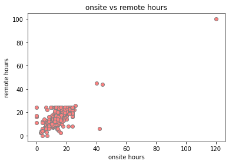

```python
# initialize a chart figure on which to plot charts
fig = plt.figure()

# these are the columns we'll be interested in using
flds = ['Response ID','var_group_1','var_name_edit','value']

# create a filter to get only the relevant time_spent variables
mask = ((df_melt4.var_name_edit.str.contains('time_spent')) \
         & (df_melt4.year == 2020) \
         & (df_melt4.var_name_edit.str.endswith('this_year') == False) \
         & (df_melt4.var_name_edit.str.endswith('last_year') == False) \
         & (df_melt4.var_name_edit.str.endswith('3mo') == False)
        )

# create a copy of the slice of the melted dataframe
# which contains only the data we want to chart
df_chart = df_melt4.loc[mask,flds].copy()

# since we now only have time spent data in df_chart, we can convert value to float
df_chart.value = df_chart.value.astype(float)

# take the leading 6 characters of the variable name
# and put them in the var_group_1 column
df_chart['var_group_1'] = df_chart['var_name_edit'].str[:6]

# df_chart = df_chart.drop('var_name_edit',axis=1)

# get rid of unnecessary fields from the flds list
flds.remove('value')
flds.remove('var_name_edit')

# sum the value by the remaining grouping fields
df_chartsum = pd.DataFrame(df_chart.groupby(flds)['value'].sum()).reset_index()

# plot a scatterplot with onsite on Y and remote on X
# apply some minor changes to formatting
plt.scatter(df_chartsum.loc[df_chartsum.var_group_1 == 'onsite']['value'],
            df_chartsum.loc[df_chartsum.var_group_1 == 'remote']['value'],
            color=[1,0.5,0.5],
            edgecolor='grey')

# give the axes and chart titles
plt.xlabel('onsite hours')
plt.ylabel('remote hours')
plt.title('onsite vs remote hours')

# show the chart
plt.show()
```

So there are clearly some people who didn't understand the question. We can get just those people:

```python
df_timespenterrors = df_chartsum.loc[df_chartsum.value > 24].copy().reset_index().drop('index',axis=1)
df_timespenterrors
```

|  | Response ID | var_group_1 | value |
| --- | --- | --- | --- |
| 0 | 1406 | onsite | 44.0 |
| 1 | 1406 | remote | 44.0 |
| 2 | 1433 | onsite | 120.0 |
| 3 | 1433 | remote | 100.0 |
| 4 | 1461 | onsite | 42.0 |
| 5 | 1471 | onsite | 25.0 |
| 6 | 1474 | onsite | 26.0 |
| 7 | 1474 | remote | 26.0 |
| 8 | 1494 | onsite | 40.0 |
| 9 | 1494 | remote | 45.0 |

And get the raw data for those people only:

```python
df_timespenterrors2 = pd.merge(df_chart,df_timespenterrors,on=['Response ID','var_group_1'])
df_timespenterrors2
```

|  | Response ID | var_group_1 | var_name_edit | value_x | value_y |
| --- | --- | --- | --- | --- | --- |
| 0 | 1406 | onsite | onsite_time_spent_prep | 3.0 | 44.0 |
| 1 | 1406 | onsite | onsite_time_spent_working | 33.0 | 44.0 |
| 2 | 1406 | onsite | onsite_time_spent_personal | 4.0 | 44.0 |
| 3 | 1406 | onsite | onsite_time_spent_caring | 4.0 | 44.0 |
| 4 | 1433 | onsite | onsite_time_spent_prep | 20.0 | 120.0 |
| 5 | 1433 | onsite | onsite_time_spent_working | 60.0 | 120.0 |
| 6 | 1433 | onsite | onsite_time_spent_personal | 20.0 | 120.0 |
| 7 | 1433 | onsite | onsite_time_spent_caring | 20.0 | 120.0 |
| 8 | 1461 | onsite | onsite_time_spent_prep | 1.0 | 42.0 |
| 9 | 1461 | onsite | onsite_time_spent_working | 32.0 | 42.0 |
| 10 | 1461 | onsite | onsite_time_spent_personal | 4.0 | 42.0 |
| 11 | 1461 | onsite | onsite_time_spent_caring | 5.0 | 42.0 |
| 12 | 1471 | onsite | onsite_time_spent_prep | 3.0 | 25.0 |
| 13 | 1471 | onsite | onsite_time_spent_working | 10.0 | 25.0 |
| 14 | 1471 | onsite | onsite_time_spent_personal | 8.0 | 25.0 |
| 15 | 1471 | onsite | onsite_time_spent_caring | 4.0 | 25.0 |
| 16 | 1474 | onsite | onsite_time_spent_prep | 4.0 | 26.0 |
| 17 | 1474 | onsite | onsite_time_spent_working | 6.0 | 26.0 |
| 18 | 1474 | onsite | onsite_time_spent_personal | 8.0 | 26.0 |
| 19 | 1474 | onsite | onsite_time_spent_caring | 8.0 | 26.0 |
| 20 | 1494 | onsite | onsite_time_spent_prep | 15.0 | 40.0 |
| 21 | 1494 | onsite | onsite_time_spent_working | 10.0 | 40.0 |
| 22 | 1494 | onsite | onsite_time_spent_personal | 5.0 | 40.0 |
| 23 | 1494 | onsite | onsite_time_spent_caring | 10.0 | 40.0 |
| 24 | 1406 | remote | remote_time_spent_prep | 3.0 | 44.0 |
| 25 | 1406 | remote | remote_time_spent_working | 33.0 | 44.0 |
| 26 | 1406 | remote | remote_time_spent_personal | 4.0 | 44.0 |
| 27 | 1406 | remote | remote_time_spent_caring | 4.0 | 44.0 |
| 28 | 1433 | remote | remote_time_spent_prep | 20.0 | 100.0 |
| 29 | 1433 | remote | remote_time_spent_working | 40.0 | 100.0 |
| 30 | 1433 | remote | remote_time_spent_personal | 20.0 | 100.0 |
| 31 | 1433 | remote | remote_time_spent_caring | 20.0 | 100.0 |
| 32 | 1474 | remote | remote_time_spent_prep | 5.0 | 26.0 |
| 33 | 1474 | remote | remote_time_spent_working | 8.0 | 26.0 |
| 34 | 1474 | remote | remote_time_spent_personal | 6.0 | 26.0 |
| 35 | 1474 | remote | remote_time_spent_caring | 7.0 | 26.0 |
| 36 | 1494 | remote | remote_time_spent_prep | 15.0 | 45.0 |
| 37 | 1494 | remote | remote_time_spent_working | 15.0 | 45.0 |
| 38 | 1494 | remote | remote_time_spent_personal | 10.0 | 45.0 |
| 39 | 1494 | remote | remote_time_spent_caring | 5.0 | 45.0 |

Looking at the results above, we can make the assumption that these respondents answered per week rather than per day.

In which case, we can divide their values by 5 to get responses per business day, assuming a 5 day week.

```python
df_timespenterrors2['factor'] = 0.2
df_timespenterrors2['year'] = 2020
df_timespenterrors2.head()
```

|  | Response ID | var_group_1 | var_name_edit | value_x | value_y | factor | year |
| --- | --- | --- | --- | --- | --- | --- | --- |
| 0 | 1406 | onsite | onsite_time_spent_prep | 3.0 | 44.0 | 0.2 | 2020 |
| 1 | 1406 | onsite | onsite_time_spent_working | 33.0 | 44.0 | 0.2 | 2020 |
| 2 | 1406 | onsite | onsite_time_spent_personal | 4.0 | 44.0 | 0.2 | 2020 |
| 3 | 1406 | onsite | onsite_time_spent_caring | 4.0 | 44.0 | 0.2 | 2020 |
| 4 | 1433 | onsite | onsite_time_spent_prep | 20.0 | 120.0 | 0.2 | 2020 |

We merge the main melted dataset with these errors using a left join, effectively adding a column with the factor to apply (0.2)

```python
# perform the merge and create a new dataframe
df_melt5 = pd.merge(df_melt4, df_timespenterrors2, on=['year','Response ID','var_name_edit'], how='left')

# show the column headers
df_melt5.head()
```

|  | year | Response ID | variable | value | col_name | var_name_edit | var_group_1_x | var_group_1_y | value_x | value_y | factor |
| --- | --- | --- | --- | --- | --- | --- | --- | --- | --- | --- | --- |
| 0 | 2020 | 1 | What year were you born? | 1972 | What year were you born? | year_born | Demographics | NaN | NaN | NaN | NaN |
| 1 | 2020 | 2 | What year were you born? | 1972 | What year were you born? | year_born | Demographics | NaN | NaN | NaN | NaN |
| 2 | 2020 | 3 | What year were you born? | 1982 | What year were you born? | year_born | Demographics | NaN | NaN | NaN | NaN |
| 3 | 2020 | 4 | What year were you born? | 1987 | What year were you born? | year_born | Demographics | NaN | NaN | NaN | NaN |
| 4 | 2020 | 5 | What year were you born? | 1991 | What year were you born? | year_born | Demographics | NaN | NaN | NaN | NaN |

var_group_1_y is a newly added variable and where it is null, it represents rows that were not part of the time spent errors.

So, we filter the data frame for where that column is not NaN and then set the value to be the multiplication of value and factor.

This effectively shrinks those values in error to one fifth of their previous magnitude.

```python
# create a filter for just those rows with a factor
mask = (df_melt5.var_group_1_y.isna() == False)

# apply the transformation to the value just on the filtered rows
df_melt5.loc[mask,'value'] = df_melt5.loc[mask]['value'].astype(float) * df_melt5.loc[mask]['factor']

# get rid of the extra columns that we no longer need
df_melt5.drop(['var_group_1_y','value_x','value_y','factor'],axis=1,inplace=True)

# reset the column names to how they were before the merge
df_melt5.rename(columns = {'var_group_1_x':'var_group_1'}, inplace = True)

# show the transformed data
df_melt5.loc[mask].head()
```

|  | year | Response ID | variable | value | col_name | var_name_edit | var_group_1 |
| --- | --- | --- | --- | --- | --- | --- | --- |
| 49629 | 2020 | 1406 | On a day when you attend your employer's workplace, how many hours would you spend doing the following activities? - Preparing for work and commuting | 0.6 | On a day when you attend your employer's workplace, how many hours would you spend doing the following activities? - Preparing for work and commuting | onsite_time_spent_prep | Time spent |
| 49656 | 2020 | 1433 | On a day when you attend your employer's workplace, how many hours would you spend doing the following activities? - Preparing for work and commuting | 4.0 | On a day when you attend your employer's workplace, how many hours would you spend doing the following activities? - Preparing for work and commuting | onsite_time_spent_prep | Time spent |
| 49684 | 2020 | 1461 | On a day when you attend your employer's workplace, how many hours would you spend doing the following activities? - Preparing for work and commuting | 0.2 | On a day when you attend your employer's workplace, how many hours would you spend doing the following activities? - Preparing for work and commuting | onsite_time_spent_prep | Time spent |
| 49694 | 2020 | 1471 | On a day when you attend your employer's workplace, how many hours would you spend doing the following activities? - Preparing for work and commuting | 0.6 | On a day when you attend your employer's workplace, how many hours would you spend doing the following activities? - Preparing for work and commuting | onsite_time_spent_prep | Time spent |
| 49697 | 2020 | 1474 | On a day when you attend your employer's workplace, how many hours would you spend doing the following activities? - Preparing for work and commuting | 0.8 | On a day when you attend your employer's workplace, how many hours would you spend doing the following activities? - Preparing for work and commuting | onsite_time_spent_prep | Time spent |

Now we create a similar chart, to show that the outliers are gone

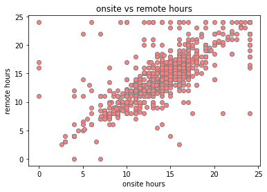

```python
fig = plt.figure()

flds = ['Response ID','var_group_1','var_name_edit','value']

mask = ((df_melt5.var_name_edit.str.contains('time_spent')) \
         & (df_melt5.year == 2020) \
         & (df_melt5.var_name_edit.str.endswith('this_year') == False) \
         & (df_melt5.var_name_edit.str.endswith('last_year') == False) \
         & (df_melt5.var_name_edit.str.endswith('3mo') == False)
        )


df_chart = df_melt5.loc[mask,flds].copy()

df_chart.value = df_chart.value.astype(float)

df_chart['var_group_1'] = df_chart['var_name_edit'].str[:6]

# df_chart = df_chart.drop('var_name_edit',axis=1)

flds.remove('value')
flds.remove('var_name_edit')

df_chartsum = pd.DataFrame(df_chart.groupby(flds)['value'].sum()).reset_index()

plt.scatter(df_chartsum.loc[df_chartsum.var_group_1 == 'onsite']['value'],
            df_chartsum.loc[df_chartsum.var_group_1 == 'remote']['value'],
            color=[1,0.5,0.5],
            edgecolor='grey')
plt.xlabel('onsite hours')
plt.ylabel('remote hours')
plt.title('onsite vs remote hours')
plt.show()
```

```python
# transpose the data to a wide format using the standardized column 'var_name_edit'
df_both = df_melt5.pivot(index = ['Response ID','year'],
                                 columns = 'var_name_edit',
                                 values = 'value').reset_index()
```

We also apply some additional cleaning. Here we are splitting the "occupation" in 2021 to "occupation" and "occupation_detail" by ' - ', then applying the same workers transform we applied earlier.

```python
# for 2021 rows, update the occupation and occupation_detail columns to be the values
# obtained by splitting the occupation column on ' - '
flds = ['occupation','occupation_detail']
mask = (df_both.year == 2021) & (df_both.occupation.str.contains(' - '))

df_both.loc[mask,flds] = df_both.loc[mask]['occupation'].str.split(' - ',
                                                                   expand = True).values



# the operation above will have created strings ending in ' workers', which we don't want
mask = (df_both['occupation'].str.lower().str.endswith(' workers'))

# update the rows by removing the text from the end of the string
df_both.loc[mask, 'occupation'] = df_both.occupation.str[:-len(' workers')]

# check there are no more worker suffixes
df_both.occupation.unique()
```

```
array(['Clerical and administrative', 'Professionals', 'Managers',
       'Sales', 'Technicians and trades',
       'Machinery operators and drivers',
       'Community and personal service', 'Labourers'], dtype=object)
```

The household_type variable has a double-space in one of the members in 2020. Clean it up.

```python
flds = ['household_type']
mask = (df_both.year == 2020) & (df_both.household_type.str.contains('One  parent'))
df_both.loc[mask,flds] = 'One parent family with dependent children'

df_both[mask][flds]
```

| var_name_edit | household_type |
| --- | --- |
| 4 | One parent family with dependent children |
| 166 | One parent family with dependent children |
| 170 | One parent family with dependent children |
| 176 | One parent family with dependent children |
| 278 | One parent family with dependent children |
| ... | ... |
| 2934 | One parent family with dependent children |
| 2938 | One parent family with dependent children |
| 2946 | One parent family with dependent children |
| 2948 | One parent family with dependent children |
| 2990 | One parent family with dependent children |

62 rows × 1 columns

Finally we can write the standardized data to a csv for some exploratory work in Excel

```python
df_both.to_csv(s + 'df_both.csv', index = False)
```

## best-worst scaling questions

Some questions are asked several times with different options. These are usually referred to as best-worst scaling, and in survey research typically called MaxDiff.

It's important to be very careful with this kind of data as we can easily make wrong assumptions about how to use the results.

Typically we have a set of items and each item is compared to every other item in the set. In the case of remote vs. onsite, there are 12 statements. Each statement is compared to every other statement through a series of 6 questions that lists 6 of the items each. The respondent is asked to rate the best and worst statement in each set.

In this particular design, each statement is presented to the respondent 3 times. Because it is exactly 3 times for each statement for every respondent, the design is balanced and we can simply count the number of times a statement was ranked best and subtract from that the number of times it was ranked worst. This gives us a net score for each statement.

First, we begin by processing the "Remote vs onsite" question.

```python
# create a filtered copy of the melt4 dataset
mask = (df_melt5.var_name_edit.str[:16] == 'remote_vs_onsite')

# we'll create a new dataset for the best-worst scaled questions
# and begin by adding the remote_vs_onsite variables
df_bw = df_melt5.loc[mask].copy()

# create a new column that extracts the number from the variable name
# e.g. remote_vs_onsite_4_best - the number is 4
# this number represents the order in which the question was asked
# among other questions with the same wording
df_bw['question_order'] = df_bw['var_name_edit'].str[17:18].astype(int)

df_bw['var_group_2'] = df_bw['var_name_edit'].str[19:]

df_bw = df_bw.drop(['col_name'], axis=1)

# for example, we can see the count of responses at best and worst for each statement
df_bw.groupby(['var_group_1','value','var_group_2'])['Response ID'].count()
```

```
var_group_1       value                                 var_group_2
Remote vs Onsite  Managing my family responsibilities   best            733
                                                        worst           380
                  Managing my personal commitments      best           1082
                                                        worst           352
                  My daily expenses                     best            972
                                                        worst           455
                  My job satisfaction                   best            633
                                                        worst           586
                  My mental wellbeing                   best            562
                                                        worst           724
                  My on-the-job learning opportunities  best            268
                                                        worst          1070
                  My opportunities to socialise         best            274
                                                        worst          1653
                  My personal relationships             best            417
                                                        worst           464
                  My work-life balance                  best           1829
                                                        worst           453
                  My working relationships              best            285
                                                        worst          1647
                  Preparing for work and commuting      best           1485
                                                        worst           328
                  The number of hours  I work           best            502
                                                        worst           930
Name: Response ID, dtype: int64
```

There are two other questions that use best-worst scaling:

1. Barrier to remote working
2. Barrier while onsite while team is remote

```python
# create a mask of rows containing barrier but not containing direction
mask = (df_melt5.var_name_edit.str.contains('barrier')) \
        & (df_melt5.var_name_edit.str.contains('direction') == False)

# check we have the right var_name_edit values
df_melt5.loc[mask].var_name_edit.unique()
```

```
array(['remote_barrier_1_most', 'remote_barrier_1_least',
       'remote_barrier_2_most', 'remote_barrier_2_least',
       'remote_barrier_3_most', 'remote_barrier_3_least',
       'remote_barrier_4_most', 'remote_barrier_4_least',
       'remote_barrier_5_most', 'remote_barrier_5_least',
       'remote_barrier_6_most', 'remote_barrier_6_least',
       'remote_barrier_7_most', 'remote_barrier_7_least',
       'remote_barrier_8_most', 'remote_barrier_8_least',
       'remote_barrier_9_most', 'remote_barrier_9_least',
       'remote_barrier_10_most', 'remote_barrier_10_least',
       'onsite_team_remote_barrier_1_biggest',
       'onsite_team_remote_barrier_1_smallest',
       'onsite_team_remote_barrier_2_biggest',
       'onsite_team_remote_barrier_2_smallest',
       'onsite_team_remote_barrier_3_biggest',
       'onsite_team_remote_barrier_3_smallest',
       'onsite_team_remote_barrier_4_biggest',
       'onsite_team_remote_barrier_4_smallest',
       'onsite_team_remote_barrier_5_biggest',
       'onsite_team_remote_barrier_5_smallest',
       'onsite_team_remote_barrier_6_biggest',
       'onsite_team_remote_barrier_6_smallest',
       'onsite_team_remote_barrier_7_biggest',
       'onsite_team_remote_barrier_7_smallest',
       'onsite_team_remote_barrier_8_biggest',
       'onsite_team_remote_barrier_8_smallest',
       'onsite_team_remote_barrier_9_biggest',
       'onsite_team_remote_barrier_9_smallest',
       'onsite_team_remote_barrier_10_biggest',
       'onsite_team_remote_barrier_10_smallest',
       'onsite_team_remote_barrier_11_biggest',
       'onsite_team_remote_barrier_11_smallest',
       'onsite_team_remote_barrier_12_biggest',
       'onsite_team_remote_barrier_12_smallest',
       'onsite_team_remote_barrier_13_biggest',
       'onsite_team_remote_barrier_13_smallest',
       'onsite_team_remote_barrier_14_biggest',
       'onsite_team_remote_barrier_14_smallest'], dtype=object)
```

Now we append these new variables to the df_bw we created above, essentially putting all best-worst scaled questions in the same dataframe

```python
# (we already have a mask defined above)

# we'll create a new dataset for the best-worst scaled questions
# and begin by adding the remote_vs_onsite variables
df_bw = pd.concat([df_bw, df_melt5.loc[mask]])
df_bw.reset_index()

# extract the number from the variable name into the question_order column
df_bw['question_order'] = df_bw.var_name_edit.str.extract('(\d+)').unstack()[0]

# extract the last word from the variable name (least, most, smallest, biggest, etc)
df_bw['var_group_2'] = df_bw['var_name_edit'].str.rsplit('_',n=1,expand=True)[1]


df_bw = df_bw.drop(['col_name'], axis=1)

# for example, we can see the count of responses at best and worst for each statement
df_bw.groupby(['var_group_1','value','var_group_2'])['Response ID'].count()
```

```
var_group_1                        value                               var_group_2
Remote barriers                    Caring responsibilities             least          1630
                                                                       most            708
                                   Connectivity (internet connection)  least          1060
                                                                       most           1155
                                   Cyber security                      least           705
                                                                                      ...
Working onsite, colleagues remote  No answer / not applicable          smallest       8624
                                   Noisy work environment              biggest        1662
                                                                       smallest       1886
                                   Problems with audio-visual setup    biggest        1508
                                                                       smallest       1422
Name: Response ID, Length: 70, dtype: int64
```

To make data viz slightly easier, and since we won't be actually showing the best/worst, least/most etc values, we'll standardize them so we can create a simpler net score measure in Tableau

```python
# being careful to read the question before assigning a standard name (the standard name itself doesn't really matter as long as it's indicative of intent)
mapdict = {
    'best': 'good',
    'worst': 'bad',
    'most': 'bad',
    'least': 'good',
    'biggest': 'bad',
    'smallest': 'good'
}

df_bw['var_group_3'] = df_bw.var_group_2.map(mapdict)

df_bw.groupby(['var_group_1','var_group_2','var_group_3'])['Response ID'].count()
```

```
var_group_1                        var_group_2  var_group_3
Remote barriers                    least        good           15070
                                   most         bad            15070
Remote vs Onsite                   best         good            9042
                                   worst        bad             9042
Working onsite, colleagues remote  biggest      bad            21168
                                   smallest     good           21168
Name: Response ID, dtype: int64
```

So, the least impactful remote barriers are good, the most impactful are bad.

The best thing about working remotely is good, the worst is bad.

The biggest barriers to collaborating in a hybrid environment are bad, the smallest are good.

Let's write the data to csv so we can investigate in Excel or Tableau

```python
df_bw.to_csv(s + 'df_bw.csv', index = False)
```

## Barriers to remote working - state by 2021

After asking the best-worst scaling question about barriers to remote working in 2020, a follow-up was asked in 2021 in a different format using a likert scale (not improving ... improving)

We should stack these questions to get the most of them

```python
# create a filtered copy of the melt4 dataset
mask = (df_melt5.var_name_edit.str.startswith('barrier_direction'))

# we'll create a new dataset for the best-worst scaled questions
# and begin by adding the remote_vs_onsite variables
df_bd = df_melt5.loc[mask].copy()

df_bd = df_bd.drop(['col_name'], axis=1)

# the particular attribute being asked about is embedded in the question text
df_bd['var_group_2'] = df_bd.variable.str.rsplit(' - ',n=1,expand=True)[1]

# for example, we can see the count of responses at best and worst for each statement
print('The unique statements being measured:')
print('')
print(df_bd.var_group_2.unique())
print('')

df_bd.groupby(['var_group_1','var_group_2','value'])['Response ID'].count()
```

```
The unique statements being measured:

['My caring responsibilities' 'Connectivity (for example internet)'
 "My organisation's software and systems"
 'Difficulty collaborating remotely' 'Poor management'
 'IT equipment (computer or printer)' 'Feeling left out and/or isolated'
 'Extra costs' 'Cyber security' "I have tasks that can't be done remotely"
 'My workspace (e.g. suitable chair, lighting, noise levels, facilities)'
 'Motivation' 'Management discourages remote working'
 'My living situation (e.g. location, home size, who I live with)'
 'Lack of remote working skills'
 'My health and safety when working remotely']
```

```
var_group_1                   var_group_2                          value
Direction of remote barriers  Connectivity (for example internet)  Not a barrier for me      294
                                                                   Significantly improved    129
                                                                   Significantly worsened     42
                                                                   Somewhat improved         289
                                                                   Somewhat worsened         160
                                                                                            ...
                              Poor management                      Significantly improved    114
                                                                   Significantly worsened     79
                                                                   Somewhat improved         218
                                                                   Somewhat worsened         156
                                                                   Stayed about the same     609
Name: Response ID, Length: 96, dtype: int64
```

```python
df_bd.to_csv(s + 'df_bd.csv', index = False)
```

## Managers impressions

Managers of remote teams were asked their opinions on a number of statements. It's useful to stack these questions for easier side-by-side stacked bars in Tableau

```python
# create a filter to get the variables for this group of questions
mask = (df_melt5.var_name_edit.str.startswith('manage_remote'))

# create a filtered copy of the main melted dataframe
df_mr = df_melt5.loc[mask].copy().reset_index()

# get rid of unwanted columns
df_mr.drop(['col_name','index'],axis=1,inplace=True)

# create a new grouping variable containing only the differentiating text
# from the var_name_edit column (essentially, the 'statement' being judged
# by the respondent
df_mr['var_group_2'] = df_mr.var_name_edit.str[14:].str.replace('_',' ')

# and finally, check the resulting dataframe
df_mr.groupby(['var_group_1','var_group_2','value'])['Response ID'].count()
```

```
var_group_1               var_group_2             value
Managing people remotely  easy contact team       Neither agree nor disagree     98
                                                  No answer / not applicable    917
                                                  Somewhat agree                253
                                                  Somewhat disagree              56
                                                  Strongly agree                171
                                                  Strongly disagree              17
                          easy poor performers    Neither agree nor disagree    157
                                                  No answer / not applicable    917
                                                  Somewhat agree                188
                                                  Somewhat disagree             115
                                                  Strongly agree                 98
                                                  Strongly disagree              37
                          easy remote management  Neither agree nor disagree    105
                                                  No answer / not applicable    917
                                                  Somewhat agree                241
                                                  Somewhat disagree              66
                                                  Strongly agree                163
                                                  Strongly disagree              20
                          feel well prepared      Neither agree nor disagree    139
                                                  No answer / not applicable    917
                                                  Somewhat agree                243
                                                  Somewhat disagree              52
                                                  Strongly agree                156
                                                  Strongly disagree               5
                          focus results           Neither agree nor disagree    138
                                                  No answer / not applicable    917
                                                  Somewhat agree                256
                                                  Somewhat disagree              43
                                                  Strongly agree                151
                                                  Strongly disagree               7
                          helps recruit           Neither agree nor disagree    196
                                                  No answer / not applicable    917
                                                  Somewhat agree                219
                                                  Somewhat disagree              32
                                                  Strongly agree                132
                                                  Strongly disagree              16
                          helps retain            Neither agree nor disagree    141
                                                  No answer / not applicable    917
                                                  Somewhat agree                255
                                                  Somewhat disagree              31
                                                  Strongly agree                152
                                                  Strongly disagree              16
                          team works well         Neither agree nor disagree    102
                                                  No answer / not applicable    917
                                                  Somewhat agree                279
                                                  Somewhat disagree              44
                                                  Strongly agree                159
                                                  Strongly disagree              11
Name: Response ID, dtype: int64
```

Write the dataframe to a csv so we can use it in Tableau

```python
df_mr.to_csv(s + 'df_mr.csv', index = False)
```